# Single-Cell RNA-Seq Analysis with Seurat

Selda Akdal

2026-03-10

# Seurat, DoubletFinder and SingleR scRNA-seq Pipeline

## Standard Preprocessing Workflow

Install and load required packages for single-cell RNA-seq analysis.

```r
# remotes::install_github('chris-mcginnis-ucsf/DoubletFinder', force = TRUE)
```

```r
library(DoubletFinder)
library(Seurat)
library(tidyverse)
```

Load raw count matrix data in MTX format using ReadMtx function

```r
cts <- ReadMtx(mtx = "GSE202501_RAW/GSM6123277_matrix.mtx.gz",
               features = "GSE202501_RAW/GSM6123277_features.tsv.gz",
               cells = "GSE202501_RAW/GSM6123277_barcodes.tsv.gz")
```

Create a Seurat object with basic filtering of low-quality cells.

```r
breastcancer <- CreateSeuratObject(counts = cts, project = "breastcancer", min.cells = 3, min.features = 200)

View(breastcancer@meta.data)
```

Calculate mitochondrial gene percentage as a quality control metric.

```r
breastcancer$percent.mt <- PercentageFeatureSet(breastcancer, pattern = "^MT-")
```

Visualize QC metrics before filtering.

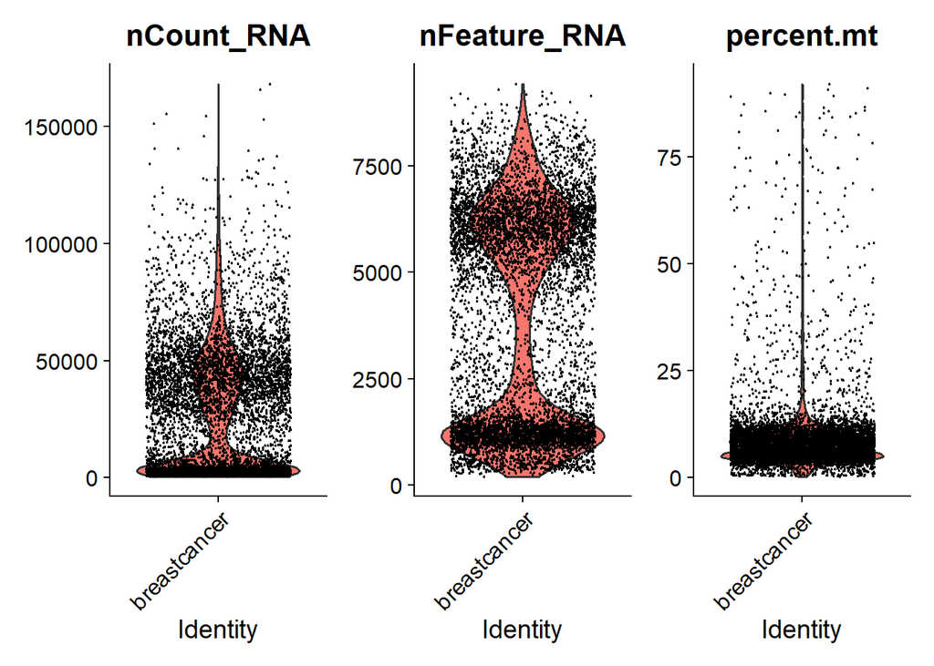

```r
VlnPlot(breastcancer, features = c("nCount_RNA", "nFeature_RNA", "percent.mt"))
```

Filter out low-quality cells based on gene count and mitochondrial content.

```r
breastcancer <- subset(breastcancer, subset = nFeature_RNA < 12500 & nFeature_RNA > 3000 & percent.mt < 20)
```

Visualize QC metrics after filtering.

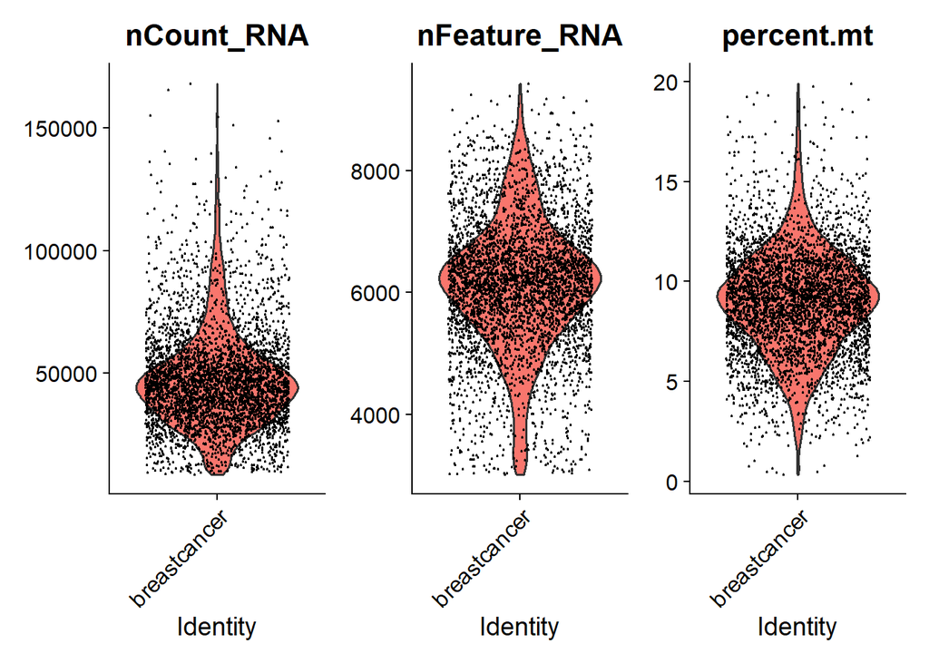

```r
VlnPlot(breastcancer, features = c("nCount_RNA", "nFeature_RNA", "percent.mt"))
```

Normalize gene expression data across all cells.

```r
breastcancer <- NormalizeData(breastcancer)
```

```
## Normalizing layer: counts
```

Identify highly variable features for downstream analysis.

```r
breastcancer <- FindVariableFeatures(breastcancer)
```

```
## Finding variable features for layer counts
```

Scale and center the data prior to dimensional reduction.

```r
breastcancer <- ScaleData(breastcancer)
```

Perform Principal Component Analysis (PCA) for dimensionality reduction.

```r
breastcancer <- RunPCA(breastcancer)
```

```
## PC_ 1
## Positive:  HMGB2, NUSAP1, MKI67, TPX2, HMGN2, STMN1, PRC1, CDKN3, TOP2A, ZWINT
##     KNL1, CENPW, PBK, CENPF, PCLAF, GTSE1, CDK1, SGO1, MAD2L1, HIST1H4C
##     NCAPG, TACC3, KIFC1, KIF20B, CENPK, KIF4A, RRM2, UBE2C, KIF11, PTTG1
## Negative:  CLDN4, EZR, AHR, SQSTM1, KLF6, FSTL3, NAMPT, HSPB1, RAB11FIP1, USP53
##     TNFRSF12A, TMEM265, AREG, PDLIM3, MACC1, CLIP1, ANXA3, NEDD9, DAPK3, NTN4
##     OCIAD2, TRIM16, SOX4, PPP1R15A, TRIM47, GPRC5A, GOLM1, SDC1, DSC2, KLF4
## PC_ 2
## Positive:  TYROBP, AIF1, SRGN, LAPTM5, FCER1G, CD74, CYBA, MSN, VIM, HLA-DPA1
##     HLA-DPB1, CTSS, ITGB2, HLA-DRB1, CCDC88A, FCGRT, HLA-DRA, LGALS1, LYZ, XIST
##     PTPRC, SAMHD1, HLA-DQB1, MS4A6A, PTPRE, PLEKHO1, S100A4, MEF2C, LST1, C1orf162
## Negative:  AZGP1, AGR2, LRRC26, PIP, GGCT, CLGN, SERHL2, H2AFV, TECR, CDKN3
##     CLU, MUCL1, H2AFZ, AC008771.1, SLPI, NUSAP1, UBE2T, ZWINT, MKI67, PBK
##     NUCB2, PRC1, CREB3L4, TOP2A, CENPF, PXMP4, HMGB3, SRARP, CDK1, KNL1
## PC_ 3
## Positive:  SFN, EZR, SPATS2L, RAB11FIP1, GPRC5A, TNFRSF12A, KLF4, OCLN, TRIM47, GSN
##     SOX4, SYNE2, MYH9, RND3, CLDN4, TAGLN2, CDC42EP3, TRIM16, ITGB8, SDCBP2
##     KLF6, AHNAK, TM4SF1, FSTL3, RAP2B, LTBP1, TMEM265, LRRFIP2, BBC3, EXPH5
## Negative:  TFAP2B, LRRC26, SRARP, PIP, MUCL1, CREB3L4, SPINK8, GLYATL1, CYB5A, SLC40A1
##     MPHOSPH6, SELENOP, AC008771.1, COMT, ALCAM, IQGAP2, DCXR, CLU, APOD, NUDT8
##     VAV3, SRD5A3, FASN, CDC42EP5, DBI, CLGN, CA12, XBP1, FBP1, SLPI
## PC_ 4
## Positive:  CCN2, TPM4, VCL, PALLD, ACTG1, MYADM, DAPK3, TRPV6, STK38L, ACTB
##     FHL2, HSPB1, ZYX, CLIP1, CNN2, GADD45B, SLC20A2, ONECUT2, LDLR, MYH9
##     CSRP1, UCP2, KRT18, FLNA, MS4A7, COBL, MYL9, WEE1, PHLDA2, CAMSAP2
## Negative:  FTH1, FTL, TKT, ADGRF1, CD47, S100A9, ZFAS1, TNFSF10, HIST1H2AC, SECTM1
##     SOX4, TSPAN1, C1orf116, NQO1, ANXA1, C4orf3, HTATIP2, PSCA, MAP2, SAT1
##     GADD45G, EGLN3, GATA3, S100A6, GPRC5A, B2M, SNHG32, SNHG5, SOX9, HIST1H4H
## PC_ 5
## Positive:  LGALS3, VSIG2, C15orf48, CEACAM6, CEACAM5, MUC21, CRABP2, INSIG1, FDFT1, MUC16
##     TSPAN3, SLC9A2, CALML5, CYP51A1, QSOX1, ILVBL, FDPS, EBP, DEGS2, FFAR2
##     DHCR7, ACAT2, TSPAN8, TSPAN1, SLC12A2, S100P, ARL6IP1, CCNB1, CXCL17, MSMO1
## Negative:  CLU, KIAA0040, ACE2, PDZK1IP1, S100A8, SPINK8, ACSL3, TNFAIP3, CEBPD, PHLDA3
##     FAH, BIRC3, USP53, KMO, CYP4X1, SQSTM1, FTH1, CPEB2, KLF10, TAGLN2
##     IL6R, CDC45, CLSPN, MT1G, TRIB1, ANKRD30A, FAM111B, PLK2, SCARA3, GLYATL1
```

Visualize principal components to select significant dimensions.

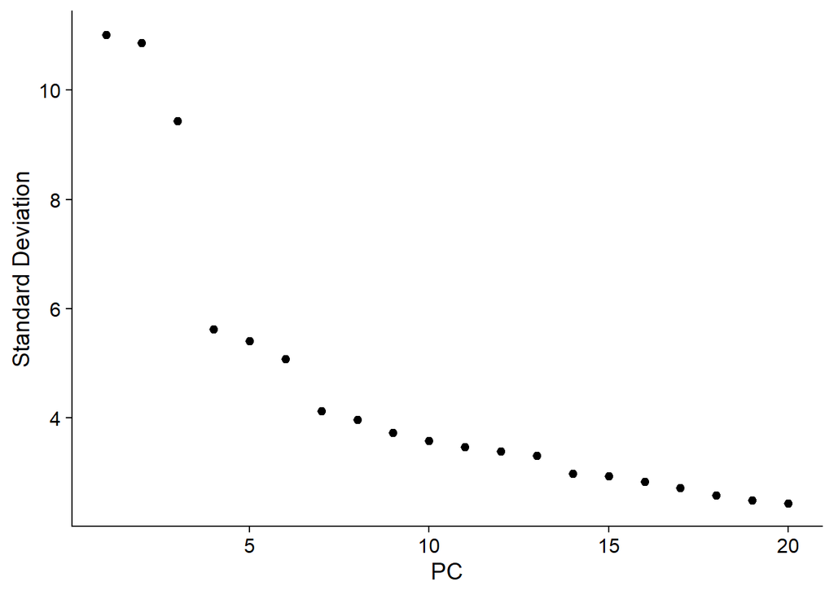

```r
ElbowPlot(breastcancer)
```

Construct nearest neighbor graph using selected principal components.

```r
breastcancer <- FindNeighbors(breastcancer, dims = 1:15)
```

Cluster cells based on gene expression similarity.

```r
breastcancer <- FindClusters(breastcancer, resolution = 0.7)
```

```
## Modularity Optimizer version 1.3.0 by Ludo Waltman and Nees Jan van Eck
##
## Number of nodes: 4235
## Number of edges: 137173
##
## Running Louvain algorithm...
## Maximum modularity in 10 random starts: 0.8013
## Number of communities: 11
## Elapsed time: 0 seconds
```

Perform UMAP for non-linear visualization of cell clusters.

```r
breastcancer <- RunUMAP(breastcancer, dims = 1:15)
```

Visualize clustered cells in reduced UMAP space.

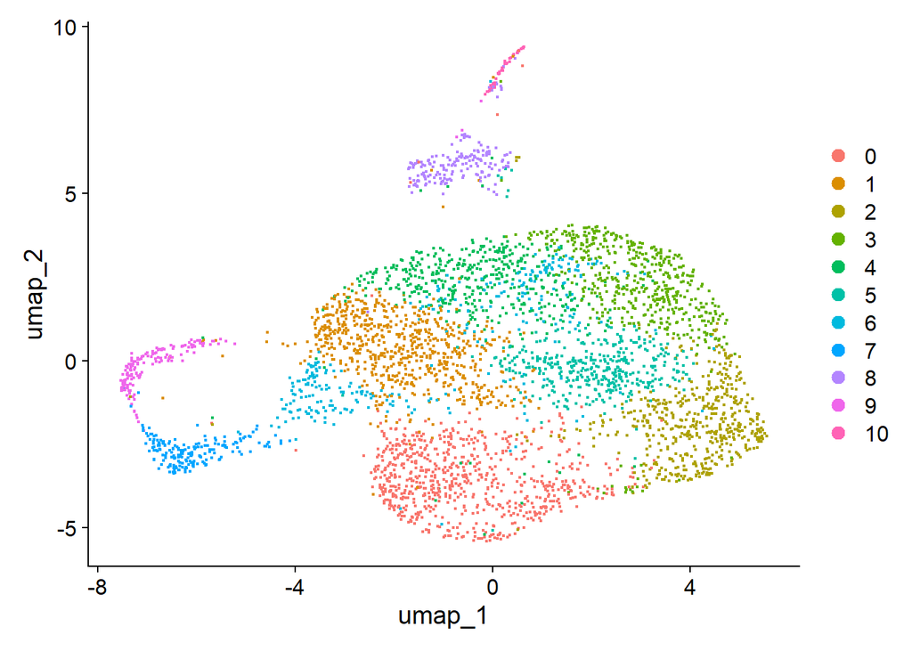

```r
DimPlot(breastcancer, reduction = "umap")
```

## Doublet Detection

Perform parameter sweep to evaluate optimal pK value for doublet detection.

```r
sweep.res.list_cancer <- paramSweep(breastcancer, PCs = 1:15, sct = FALSE)
```

```
## [1] "Creating artificial doublets for pN = 5%"
## [1] "Creating Seurat object..."
## [1] "Normalizing Seurat object..."
```

```
## Normalizing layer: counts
```

```
## [1] "Finding variable genes..."
```

```
## Finding variable features for layer counts
```

```
## [1] "Scaling data..."
```

[output not shown]

[output cut: 23 more lines]

```
## Normalizing layer: counts
```

```
## [1] "Finding variable genes..."
```

```
## Finding variable features for layer counts
```

```
## [1] "Scaling data..."
```

[output not shown]

[output cut: 23 more lines]

```
## Normalizing layer: counts
```

```
## [1] "Finding variable genes..."
```

```
## Finding variable features for layer counts
```

```
## [1] "Scaling data..."
```

[output not shown]

[output cut: 23 more lines]

```
## Normalizing layer: counts
```

```
## [1] "Finding variable genes..."
```

```
## Finding variable features for layer counts
```

```
## [1] "Scaling data..."
```

[output not shown]

[output cut: 23 more lines]

```
## Normalizing layer: counts
```

```
## [1] "Finding variable genes..."
```

```
## Finding variable features for layer counts
```

```
## [1] "Scaling data..."
```

[output not shown]

[output cut: 23 more lines]

```
## Normalizing layer: counts
```

```
## [1] "Finding variable genes..."
```

```
## Finding variable features for layer counts
```

```
## [1] "Scaling data..."
```

[output not shown]

[output cut: 20 more lines]

Summarize sweep results to evaluate doublet detection performance.

```r
sweep.stats_cancer <- summarizeSweep(sweep.res.list_cancer, GT = FALSE)
```

Identify optimal pK value based on BCmetric performance.

```r
bcmvn_cancer <- find.pK(sweep.stats_cancer)
```

[figure not shown]

Visualize BCmetric across different pK values

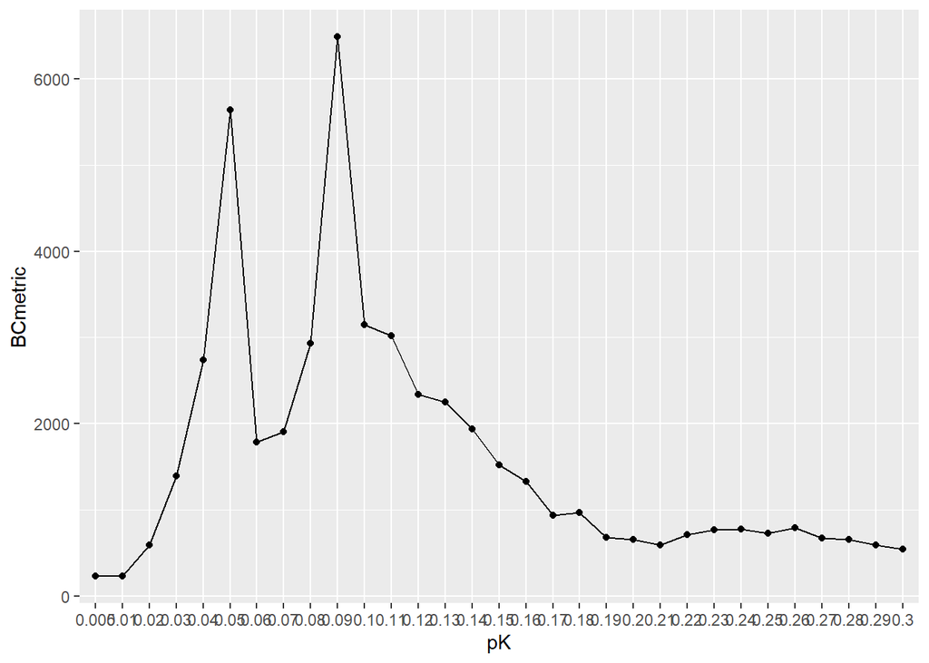

```r
ggplot(bcmvn_cancer, aes(pK, BCmetric, group = 1)) +
  geom_point() +
  geom_line()
```

Select the pK value with the highest BCmetric score.

```r
pK <- bcmvn_cancer %>%
  filter(BCmetric == max(BCmetric)) %>%
  select(pK)
```

Convert selected pK value into numeric format for analysis.

```r
pK <- as.numeric(as.character(pK[[1]]))
```

Extract cluster annotations for homotypic doublet estimation.

```r
annotations <- breastcancer@meta.data$seurat_clusters
```

Estimate proportion of homotypic doublets based on cluster identity.

```r
homotypic.prop <- modelHomotypic(annotations)
```

Estimate expected number of doublets based on dataset size.

```r
nExp_poi <- round(0.076*nrow(breastcancer@meta.data))
```

Adjust expected doublet number using homotypic proportion.

```r
nExp_poi.adj <- round(nExp_poi*(1-homotypic.prop))
```

Run DoubletFinder to identify potential doublet cells.

```r
breastcancer <- doubletFinder(breastcancer,
                              PCs = 1:15,
                              pK=pK,
                              pN=0.25,
                              nExp = nExp_poi.adj)
```

```
## [1] "Creating 1412 artificial doublets..."
## [1] "Creating Seurat object..."
## [1] "Normalizing Seurat object..."
```

```
## Normalizing layer: counts
```

```
## [1] "Finding variable genes..."
```

```
## Finding variable features for layer counts
```

```
## [1] "Scaling data..."
```

```
## [1] "Running PCA..."
## [1] "Calculating PC distance matrix..."
## [1] "Computing pANN..."
## [1] "Classifying doublets.."
```

```r
View(breastcancer@meta.data)
head(breastcancer@meta.data)
```

```
##                      orig.ident nCount_RNA nFeature_RNA percent.mt
## AAACCCACACATAACC-1 breastcancer      36961         5660   5.927870
## AAACCCATCACCTCGT-1 breastcancer      34934         5668   8.747925
## AAACGAACACATTCGA-1 breastcancer      10933         3147   4.180005
## AAACGAAGTTCTCCAC-1 breastcancer      80536         7132   9.126353
## AAACGCTCAAGCTACT-1 breastcancer      94919         8085   7.587522
## AAACGCTTCGTCAACA-1 breastcancer      44274         5955   9.328274
##                    RNA_snn_res.0.7 seurat_clusters pANN_0.25_0.09_283
## AAACCCACACATAACC-1               0               0          0.2539370
## AAACCCATCACCTCGT-1               0               0          0.2893701
## AAACGAACACATTCGA-1              10              10          0.3169291
## AAACGAAGTTCTCCAC-1               4               4          0.2578740
## AAACGCTCAAGCTACT-1               3               3          0.3917323
## AAACGCTTCGTCAACA-1               3               3          0.2460630
##                    DF.classifications_0.25_0.09_283
## AAACCCACACATAACC-1                          Singlet
## AAACCCATCACCTCGT-1                          Singlet
## AAACGAACACATTCGA-1                          Singlet
## AAACGAAGTTCTCCAC-1                          Singlet
## AAACGCTCAAGCTACT-1                          Singlet
## AAACGCTTCGTCAACA-1                          Singlet
```

Visualize predicted singlets and doublets in UMAP space.

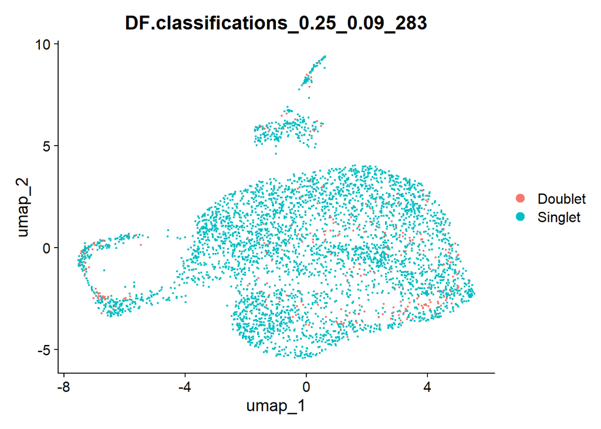

```r
DimPlot(breastcancer, reduction = "umap", group.by = "DF.classifications_0.25_0.09_283")
```

Filter out predicted doublet cells and retain only singlets.

```r
breastcancerfiltered <- subset(breastcancer, subset = DF.classifications_0.25_0.09_283 == "Singlet")
```

Re-run full preprocessing pipeline after doublet removal.

```r
breastcancerfiltered <- breastcancerfiltered %>%
  NormalizeData() %>%
  FindVariableFeatures() %>%
  ScaleData() %>%
  RunPCA() %>%
  FindNeighbors(dims = 1:15) %>%
  FindClusters() %>%
  RunUMAP(dims = 1:15)
```

```
## Normalizing layer: counts
```

```
## Finding variable features for layer counts
```

```
## PC_ 1
## Positive:  TYROBP, CD74, SRGN, FCER1G, AIF1, LAPTM5, CYBA, MSN, HLA-DPA1, HLA-DRA
##     HLA-DPB1, VIM, ITGB2, XIST, SAMHD1, LGALS1, PTPRC, HLA-DRB1, HLA-DQB1, CTSS
##     CCDC88A, PLEKHO1, FCGRT, HLA-DMB, LYZ, PTPRE, LSP1, MS4A6A, COTL1, S100A4
## Negative:  CLDN4, KRT18, EZR, PDLIM3, AQP3, HSPB1, USP53, LGALS3, AHR, TNFRSF12A
##     NAMPT, MACC1, RAB11FIP1, SDC1, SQSTM1, FSTL3, DAPK3, TMEM265, ANXA3, PALLD
##     OCLN, NTN4, CDC42EP1, CLIP1, COBL, AREG, KRT23, LDLR, OCIAD2, MISP
## PC_ 2
## Positive:  CDKN3, NUSAP1, MKI67, HMGN2, ZWINT, PBK, PRC1, TOP2A, TPX2, UBE2T
##     KNL1, CENPF, H2AFZ, CENPW, CDK1, GGCT, GTSE1, SGO1, PCLAF, CENPM
##     STMN1, H2AFV, UBE2C, MAD2L1, KIF4A, NCAPG, KIFC1, RRM2, KIF11, BIRC5
## Negative:  TYROBP, AIF1, LAPTM5, SRGN, FCER1G, MSN, CD74, CTSS, CYBA, VIM
##     HLA-DPB1, HLA-DPA1, FCGRT, LYZ, CCDC88A, HLA-DRB1, ITGB2, MS4A6A, LGALS1, PTPRE
##     CST3, MEF2C, SAMHD1, HLA-DRA, XIST, HLA-DQB1, LST1, C1orf162, PTPRC, S100A4
## PC_ 3
## Positive:  SFN, EZR, SPATS2L, GPRC5A, RAB11FIP1, OCLN, KLF4, SYNE2, TNFRSF12A, TRIM47
##     SOX4, GSN, RND3, TAGLN2, MYH9, ITGB8, CDC42EP3, CLDN4, SDCBP2, TM4SF1
##     TRIM16, EXPH5, LRRFIP2, AHNAK, LTBP1, RASSF1, RAP2B, BBC3, LMO7, KLF6
## Negative:  TFAP2B, LRRC26, SRARP, PIP, MUCL1, SELENBP1, CREB3L4, SPINK8, GLYATL1, CYB5A
##     SLC40A1, SELENOP, MPHOSPH6, COMT, IQGAP2, REEP6, ALCAM, DCXR, AC008771.1, CLU
##     APOD, NUDT8, SRD5A3, VAV3, FASN, CDC42EP5, DBI, CA12, XBP1, FBP1
## PC_ 4
## Positive:  FTH1, FTL, GLUL, ADGRF1, TKT, S100A9, ZFAS1, CD47, TNFSF10, SOX4
##     C1orf116, HIST1H2AC, ANXA1, SECTM1, NQO1, C4orf3, TSPAN1, SAT1, HTATIP2, MAP2
##     PSCA, GATA3, EGLN3, S100A6, GPRC5A, GADD45G, B2M, LCN2, SOX9, SNHG32
## Negative:  CCN2, TPM4, VCL, PALLD, ACTG1, MYADM, STK38L, DAPK3, TRPV6, ACTB
##     FHL2, HSPB1, ZYX, CLIP1, CNN2, GADD45B, ONECUT2, UCP2, LDLR, SLC20A2
##     CSRP1, KRT18, MYH9, MS4A7, FLNA, PHLDA2, COBL, MYL9, WEE1, CAMSAP2
## PC_ 5
## Positive:  SELENOM, CLU, KIAA0040, ACE2, PDZK1IP1, ACSL3, S100A8, TNFAIP3, SPINK8, USP53
##     FAH, CEBPD, BIRC3, CYP4X1, CPEB2, IL6R, SQSTM1, TRIB1, KMO, KLF10
##     ANKRD30A, FTH1, TAGLN2, MT1G, SCARA3, PLK2, NFKBIA, GLYATL1, JUNB, MAPK8IP2
## Negative:  LGALS3, VSIG2, CEACAM6, C15orf48, CEACAM5, MUC21, CRABP2, MUC16, INSIG1, CALML5
##     TSPAN3, SLC9A2, FDFT1, QSOX1, CYP51A1, EBP, FDPS, ILVBL, FFAR2, TSPAN1
##     ACAT2, TSPAN8, DEGS2, S100P, DHCR7, SLC12A2, TOX3, CXCL17, MSMO1, ARL6IP1
```

```
## Modularity Optimizer version 1.3.0 by Ludo Waltman and Nees Jan van Eck
##
## Number of nodes: 3952
## Number of edges: 129386
##
## Running Louvain algorithm...
## Maximum modularity in 10 random starts: 0.7953
## Number of communities: 13
## Elapsed time: 0 seconds
```

Visualize final clustered single-cell data.

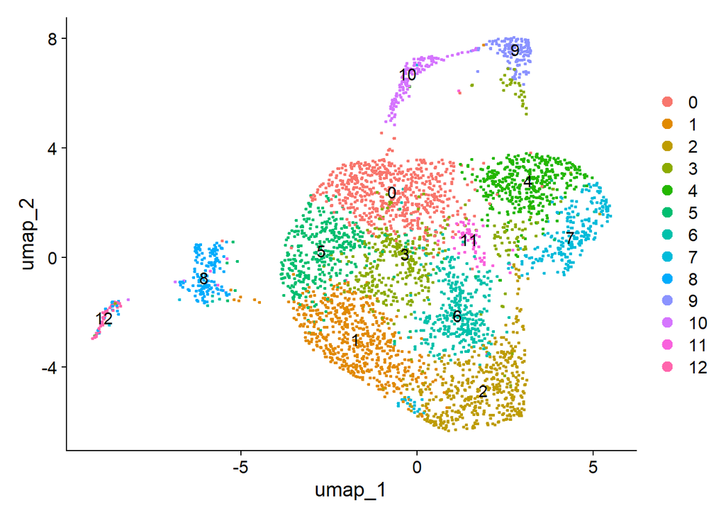

```r
DimPlot(breastcancerfiltered, reduction = "umap", label=T)
```

## Cell Type Annotation with SingleR

Install and load SingleR and reference datasets for cell type annotation.

```r
#if (!require("BiocManager", quietly = TRUE))
#  install.packages("BiocManager")

#BiocManager::install("SingleR")

#if (!require("BiocManager", quietly = TRUE))
#  install.packages("BiocManager")

#BiocManager::install("celldex")
```

```r
library(SingleR)
library(celldex)
```

Load reference dataset containing known human primary cell types.

```r
ref<- celldex::HumanPrimaryCellAtlasData()

View(as.data.frame(colData(ref)))
```

Extract normalized expression data from Seurat object for annotation.

```r
breast_counts <- GetAssayData(object = breastcancerfiltered, layer = "data")
```

Perform cell type prediction using SingleR against reference dataset.

```r
pred <- SingleR(test = breast_counts,
                ref = ref,
                labels = ref$label.main)
pred
```

```
## DataFrame with 3952 rows and 4 columns
##                                            scores           labels delta.next
##                                          <matrix>      <character>  <numeric>
## AAACCCACACATAACC-1 0.306678:0.247759:0.211841:... Epithelial_cells  0.0739406
## AAACCCATCACCTCGT-1 0.305470:0.252082:0.207265:... Epithelial_cells  0.0740008
## AAACGAACACATTCGA-1 0.164373:0.352583:0.395847:...         Monocyte  0.1373088
## AAACGAAGTTCTCCAC-1 0.326032:0.260415:0.214236:... Epithelial_cells  0.0780123
## AAACGCTCAAGCTACT-1 0.357455:0.278914:0.230948:... Epithelial_cells  0.0869385
## ...                                           ...              ...        ...
## TTTGTTGAGAACAAGG-1 0.343908:0.293963:0.243870:... Epithelial_cells  0.0809626
## TTTGTTGAGATTGAGT-1 0.311028:0.267869:0.231993:... Epithelial_cells  0.0786295
## TTTGTTGAGCCGTTGC-1 0.319478:0.258668:0.224714:... Epithelial_cells  0.0917857
## TTTGTTGCAGTTGTCA-1 0.317457:0.277034:0.242533:... Epithelial_cells  0.0866905
## TTTGTTGGTAGCGTTT-1 0.294190:0.249030:0.213912:... Epithelial_cells  0.0806194
##                       pruned.labels
##                         <character>
## AAACCCACACATAACC-1 Epithelial_cells
## AAACCCATCACCTCGT-1 Epithelial_cells
## AAACGAACACATTCGA-1         Monocyte
## AAACGAAGTTCTCCAC-1 Epithelial_cells
## AAACGCTCAAGCTACT-1 Epithelial_cells
## ...                             ...
## TTTGTTGAGAACAAGG-1 Epithelial_cells
## TTTGTTGAGATTGAGT-1 Epithelial_cells
## TTTGTTGAGCCGTTGC-1 Epithelial_cells
## TTTGTTGCAGTTGTCA-1 Epithelial_cells
## TTTGTTGGTAGCGTTT-1 Epithelial_cells
```

Assign predicted cell types back into Seurat metadata.

```r
breastcancerfiltered$singleR <- pred$labels

head(breastcancerfiltered@meta.data)
```

```
##                      orig.ident nCount_RNA nFeature_RNA percent.mt
## AAACCCACACATAACC-1 breastcancer      36961         5660   5.927870
## AAACCCATCACCTCGT-1 breastcancer      34934         5668   8.747925
## AAACGAACACATTCGA-1 breastcancer      10933         3147   4.180005
## AAACGAAGTTCTCCAC-1 breastcancer      80536         7132   9.126353
## AAACGCTCAAGCTACT-1 breastcancer      94919         8085   7.587522
## AAACGCTTCGTCAACA-1 breastcancer      44274         5955   9.328274
##                    RNA_snn_res.0.7 seurat_clusters pANN_0.25_0.09_283
## AAACCCACACATAACC-1               0               4          0.2539370
## AAACCCATCACCTCGT-1               0               4          0.2893701
## AAACGAACACATTCGA-1              10              12          0.3169291
## AAACGAAGTTCTCCAC-1               4               5          0.2578740
## AAACGCTCAAGCTACT-1               3               7          0.3917323
## AAACGCTTCGTCAACA-1               3               1          0.2460630
##                    DF.classifications_0.25_0.09_283 RNA_snn_res.0.8
## AAACCCACACATAACC-1                          Singlet               4
## AAACCCATCACCTCGT-1                          Singlet               4
## AAACGAACACATTCGA-1                          Singlet              12
## AAACGAAGTTCTCCAC-1                          Singlet               5
## AAACGCTCAAGCTACT-1                          Singlet               7
## AAACGCTTCGTCAACA-1                          Singlet               1
##                             singleR
## AAACCCACACATAACC-1 Epithelial_cells
## AAACCCATCACCTCGT-1 Epithelial_cells
## AAACGAACACATTCGA-1         Monocyte
## AAACGAAGTTCTCCAC-1 Epithelial_cells
## AAACGCTCAAGCTACT-1 Epithelial_cells
## AAACGCTTCGTCAACA-1 Epithelial_cells
```

```r
View(breastcancerfiltered@meta.data)
```

Visualize annotated cell types on UMAP plot.

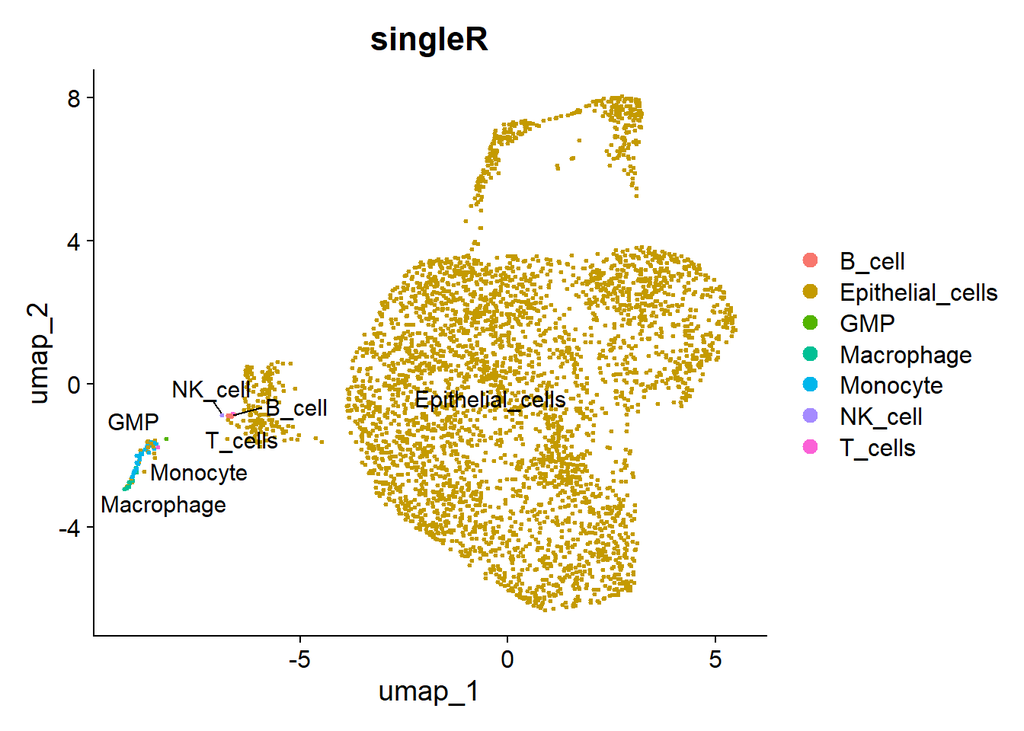

```r
a1<- DimPlot(breastcancerfiltered, reduction = "umap", group.by = "singleR", label=T, repel=T)

a1
```

Define SingleR-based identities for downstream marker analysis.

```r
Idents(breastcancerfiltered) <- breastcancerfiltered$singleR
```

Identify cluster-specific marker genes.

```r
breast.markers <- FindAllMarkers(breastcancerfiltered, only.pos = TRUE)
```

[output not shown]

Visualize selected marker gene expression across cell populations.

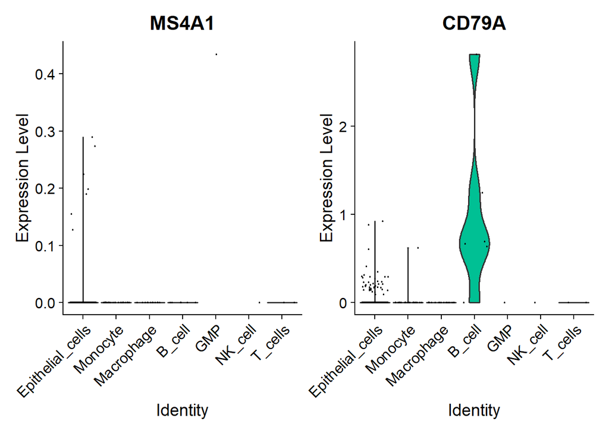

```r
VlnPlot(breastcancerfiltered, features = c("MS4A1", "CD79A"))
```

Generate feature plots for selected immune-related genes.

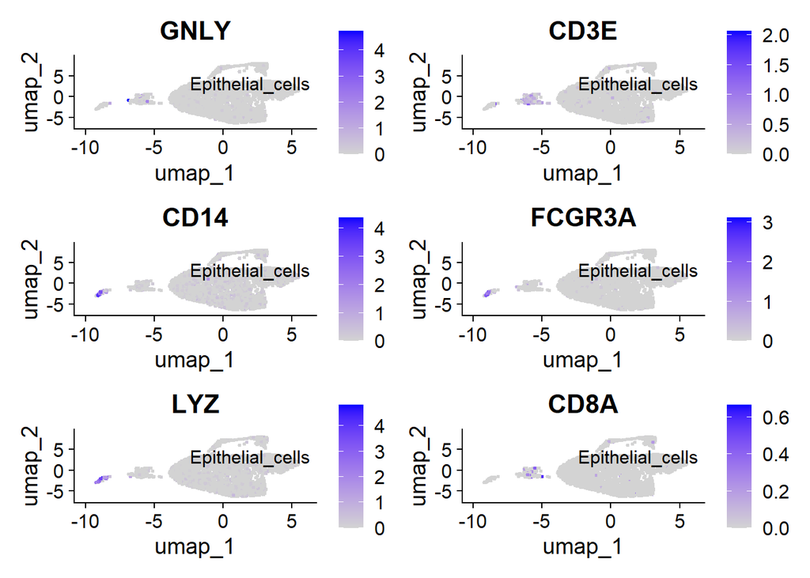

```r
b1<- FeaturePlot(breastcancerfiltered, features = c("GNLY", "CD3E", "CD14", "FCGR3A", "LYZ",
                                               "CD8A"), label=T, repel = T)
b1
```

Save visualization outputs as image files for reporting or publication.

```r
ggsave("a1.png", width = 10, height = 8)
ggsave("b1.png", width = 10, height = 8)
```